# NSCI7915 Preliminary Analysis

*Table 7: Levenes test for homogeneity of variance*

|  | Df | F value | Pr(>F) |
| --- | --- | --- | --- |
| group | 3 | 0.4504796 | 0.7177922 |
|  | 67 | NA | NA |

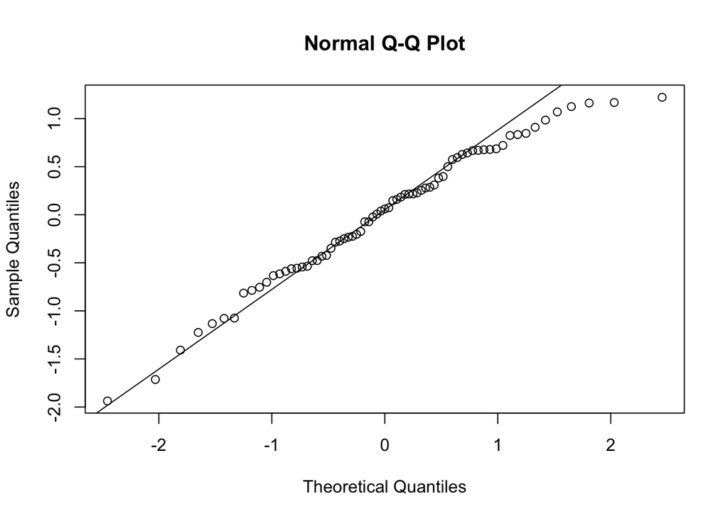

*Figure 4: QQ plot for ANOVA model*

**Results**

**Assumptions of Analyses**

**Independence of observations**: No two observations in the dataset are related to each other or affect each other in any way.

**Normal distribution**: The data is normally distributed (refer to figure 4)

**Linearity**: The relationship between Date and the volume of H.perlevis is linear

**Homogeneity of variance**: The variance of the volume of H.perlevis is equal across all groups for the months (tested with levenes test)

**Hypothesis 3: Is there a relationship between average volume of H.perlevis per month and pH, salinity and temperature averages for the months**

Metadata from: Nudibranch predation boosts sponge silicon cycling (2023) Temp,Salinity and pH values obtained from Somlit.

IV= average Temp (T), Salinity (S) and PH values for the month the volume was measured

D= average sponge volume per month (mL sponge m-2) given by ((ponge volume mL./abundance) per quadrant, averages for the months)

Null Hypothesis (H0): There is no signfiicant relationship between the average volume of H.perlevis per month (D) and the average temperature (T), salinity (S), and pH values for the corresponding months.

Alternative Hypothesis (HA): There is a signfiicant relationship between the average volume of H.perlevis per month (D) and the average temperature (T), salinity (S), and pH values for the corresponding months.

Analyses: pearsons correlation

*Table 8: Summary statistics for temperature, salinity and pH data from SOMLIT*

```
##     ID_SITE      DATE                 T               S               PH
##  Min.   :5   Length:14          Min.   :10.97   Min.   :33.62   Min.   :7.791
##  1st Qu.:5   Class :character   1st Qu.:12.90   1st Qu.:34.34   1st Qu.:7.885
##  Median :5   Mode  :character   Median :14.24   Median :34.59   Median :7.920
##  Mean   :5                      Mean   :14.03   Mean   :34.48   Mean   :7.921
##  3rd Qu.:5                      3rd Qu.:15.62   3rd Qu.:34.73   3rd Qu.:7.950
##  Max.   :5                      Max.   :16.82   Max.   :35.01   Max.   :8.138
```

```
## [1] "Standard Deviation (T): 2.02518274307706 Standard Deviation (pH): 0.0953984414828807 Standard Deviation (Sal): 0.394383926293507"
```

*Table 9: Averages data for Temp, pH, salinity and volume per month brackets*

```
##   Month Year        T        S       PH
## 1     6 2020 16.04400 34.68967 8.016667
## 2    11 2020 13.13850 34.46150 7.859750
## 3     4 2021 11.09100 33.85867 7.913333
## 4     6 2021 15.61075 34.81675 7.915000
```

```
##    Date Volumen.Hym..mL./N.H..perlevis
## 1 Apr21                      3.8781924
## 2 Jun20                     12.6688840
## 3 Jun21                      3.0448443
## 4 Nov20                      0.8122513
```

*Table 10: Correlation analysis for volume of H.perlevis vs T,S and pH*

```
##                                Volumen.Hym..mL..N.H..perlevis          T
## Volumen.Hym..mL..N.H..perlevis                     1.00000000 -0.2758412
## T                                                 -0.27584123  1.0000000
## S                                                 -0.08480915  0.9491472
## PH                                                -0.52623615  0.5763816
##                                          S         PH
## Volumen.Hym..mL..N.H..perlevis -0.08480915 -0.5262361
## T                               0.94914725  0.5763816
## S                               1.00000000  0.2922510
## PH                              0.29225097  1.0000000
```

**Results**

A correlation test was used to show the relationship between volume of H.perlevis for the different months and T, S and Ph for the corresponding month. Volume had a weak negative correlation with temperature (r= -0.276) and a weak negative correlation with salinity (r= -0.085). It has a moderate negative correlation with the variable pH (r= -0.526).

**Assumption of Analyses**

**Independence of observations**: No two observations in the dataset are related to each other or affect each other in any way.

**Linearity**: The relationship between Date and the volume of H.perlevis is linear

**Homogeneity of variance**: The variance of the volume of H.perlevis is equal across all groups for the months.

**Hypothesis 4: What is the relationship between the abundance of H.perlevis and biomass per haibitat (2022 study)**

metadata: Sponge contribution to the silicon cycle of a diatom-rich shallow bay (2022) IV= habitat& abundance (N sponge m-2) D= biomass (mL sponge m-2) Habitats= Rocky intertidal,Rocky subtidal,Maerl,Shallow muds,Heterog seds,Circ.coarse seds

Null Hypothesis (H0): There is no significant relationship between biomass and the interaction between Habitat and abundance

Alternative Hypothesis (HA): There is a significant relationship between biomass and the interaction between Habitat and abundance

Analyses: scatterplot, correlation test, linear regression analysis, anova (m10b and m10), regression analysis

*Table 11: Summary statistics for abundance (N sponge m-2) and biomass (mL sponge m-2) of H.perlevis sponges from 2022 study*

```
##        N          Habitat          Abundance.sponges Sponge.biomass
##  Min.   : 1.0   Length:142         Min.   : 1.00     Min.   :    3.75
##  1st Qu.: 8.0   Class :character   1st Qu.: 3.00     1st Qu.:   35.21
##  Median :15.5   Mode  :character   Median : 7.00     Median :  131.58
##  Mean   :16.5                      Mean   :12.77     Mean   :  985.79
##  3rd Qu.:24.0                      3rd Qu.:15.00     3rd Qu.:  388.68
##  Max.   :40.0                      Max.   :92.00     Max.   :47446.35
##
##      row_id
##  1      :  1
##  2      :  1
##  3      :  1
##  4      :  1
##  5      :  1
##  6      :  1
##  (Other):136
```

```
## [1] "Standard Deviation (Abundance): 17.1338764821148 Standard Deviation (Biomass): 4739.46115648504"
```

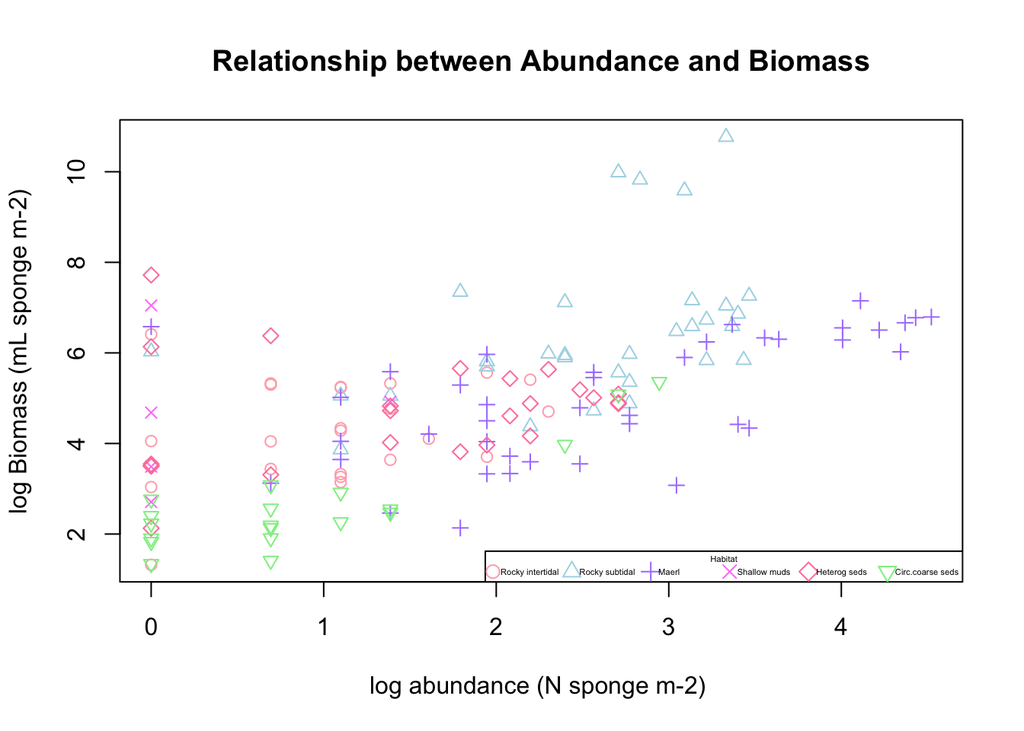

*Figure 5: Scatterplot of the relationship between (x): log abundance (N sponge m-2) and (y): log biomass (mL sponges m-2), per habitat.*

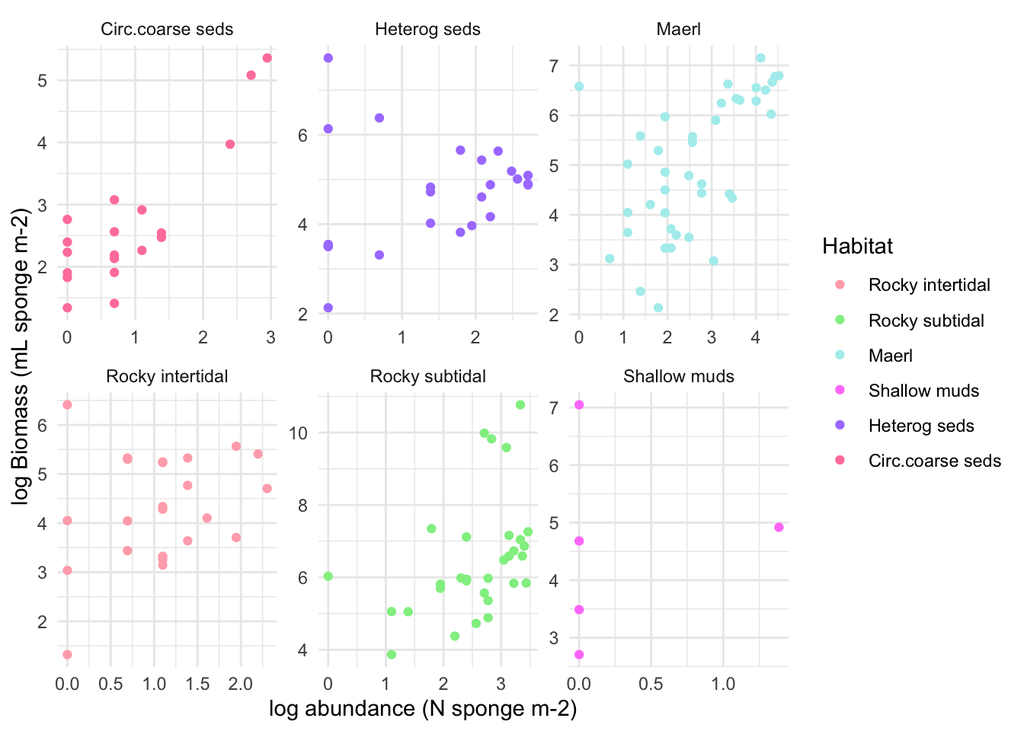

*Figure 6: Scatterplots of the relationship between (x): log abundance (N sponge m-2) and (y): log biomass (mL sponges m-2), per habitat. Representation 2 using ggplot plugin.*

*Table 12: Correlation analysis between abundance and biomass of H.perlevis. For hypothesis 4.*

```
## [1] 0.1208355
```

|  | Res.Df | RSS | Df | Sum of Sq | F | Pr(>F) |
| --- | --- | --- | --- | --- | --- | --- |
| 1 | 135 | 196.2390 | NA | NA | NA | NA |
| 2 | 130 | 188.1783 | 5 | 8.060756 | 1.113729 | 0.3562935 |

*Table 14: Summary of M1*

```
##
## Call:
## lm(formula = log.biomass ~ Habitat + log.n, data = data2022)
##
## Residuals:
##     Min      1Q  Median      3Q     Max
## -2.3431 -0.6598 -0.2098  0.5976  3.9337
##
## Coefficients:
##                         Estimate Std. Error t value Pr(>|t|)
## (Intercept)               2.0795     0.2935   7.085 6.96e-11 ***
## HabitatHeterog seds       1.7064     0.3752   4.548 1.19e-05 ***
## HabitatMaerl              1.2676     0.3837   3.304 0.001221 **
## HabitatRocky intertidal   1.5486     0.3742   4.138 6.12e-05 ***
## HabitatRocky subtidal     2.7984     0.3944   7.094 6.64e-11 ***
## HabitatShallow muds       2.3146     0.6098   3.796 0.000222 ***
## log.n                     0.6314     0.1085   5.816 4.15e-08 ***
## ---
## Signif. codes:  0 '***' 0.001 '**' 0.01 '*' 0.05 '.' 0.1 ' ' 1
##
## Residual standard error: 1.206 on 135 degrees of freedom
## Multiple R-squared:  0.5431, Adjusted R-squared:  0.5228
## F-statistic: 26.75 on 6 and 135 DF,  p-value: < 2.2e-16
```

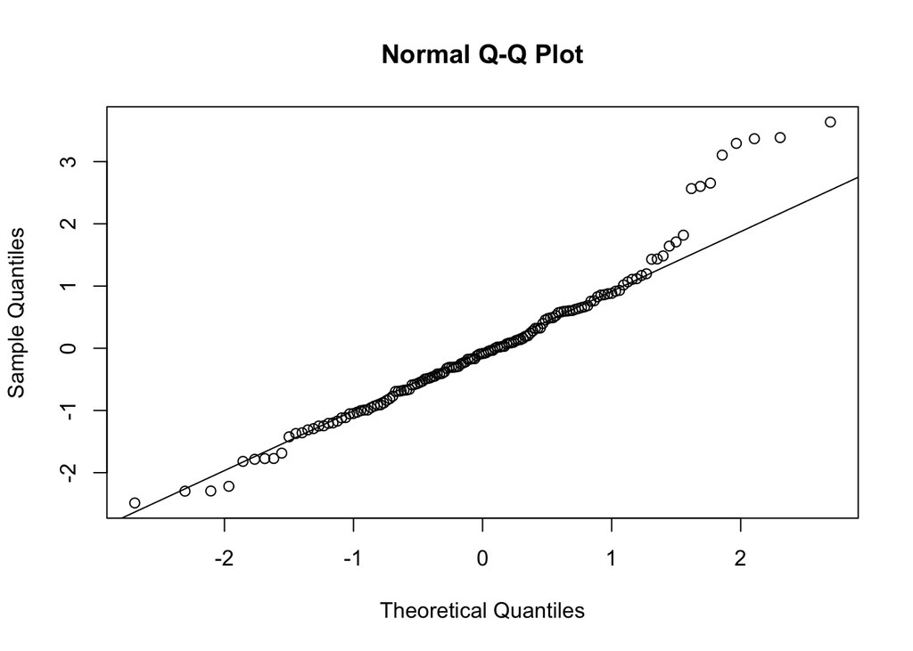

*Figure 7: QQ plot for ANOVA model in hypothesis 4*

**Results**

**Assumption of Analyses**

**Independence of observations**:No two observations in the dataset are related to each other or affect each other in any way.

**Linearity**: The relationship between abundance and biomass of H.perlevis is linear

**Homogeneity of variance**: The variance of the volume of H.perlevis is equal across all groups for the habitats.